# Class10

Samuel Do (PID:A15803613)

2/17/2022

```r
#read genotype file\
mxl <- read.csv("373531-SampleGenotypes-Homo_sapiens_Variation_Sample_rs8067378.csv")
mxl
```

```
##    Sample..Male.Female.Unknown. Genotype..forward.strand. Population.s. Father
## 1                   NA19648 (F)                       A|A ALL, AMR, MXL      -
## 2                   NA19649 (M)                       G|G ALL, AMR, MXL      -
## 3                   NA19651 (F)                       A|A ALL, AMR, MXL      -
## 4                   NA19652 (M)                       G|G ALL, AMR, MXL      -
## 5                   NA19654 (F)                       G|G ALL, AMR, MXL      -
## 6                   NA19655 (M)                       A|G ALL, AMR, MXL      -
## 7                   NA19657 (F)                       A|G ALL, AMR, MXL      -
## 8                   NA19658 (M)                       A|A ALL, AMR, MXL      -
## 9                   NA19661 (M)                       A|G ALL, AMR, MXL      -
## 10                  NA19663 (F)                       A|A ALL, AMR, MXL      -
## 11                  NA19664 (M)                       G|A ALL, AMR, MXL      -
## 12                  NA19669 (F)                       A|A ALL, AMR, MXL      -
## 13                  NA19670 (M)                       A|A ALL, AMR, MXL      -
## 14                  NA19676 (M)                       G|G ALL, AMR, MXL      -
```

[output cut: 115 more lines]

```r
table(mxl$Genotype..forward.strand.)/nrow(mxl)
```

```
##
##      A|A      A|G      G|A      G|G
## 0.343750 0.328125 0.187500 0.140625
```

# Section 4: Population Scale Analysis

[Q13] Determine the sample size for each genotype and their corresponding median expression levels for each of these genotypes.

```r
expr <- read.table("rs8067378_ENSG00000172057.6.txt")
head(expr)
```

```
##    sample geno      exp
## 1 HG00367  A/G 28.96038
## 2 NA20768  A/G 20.24449
## 3 HG00361  A/A 31.32628
## 4 HG00135  A/A 34.11169
## 5 NA18870  G/G 18.25141
## 6 NA11993  A/A 32.89721
```

```r
nrow(expr)
```

```
## [1] 462
```

```r
table(expr$geno)
```

```
##
## A/A A/G G/G
## 108 233 121
```

```r
summary(expr)
```

```
##     sample              geno                exp
##  Length:462         Length:462         Min.   : 6.675
##  Class :character   Class :character   1st Qu.:20.004
##  Mode  :character   Mode  :character   Median :25.116
##                                        Mean   :25.640
##                                        3rd Qu.:30.779
##                                        Max.   :51.518
```

```r
aggregate(x=expr$exp,
          by=list(expr$geno),
          FUN=median)
```

```
##   Group.1        x
## 1     A/A 31.24847
## 2     A/G 25.06486
## 3     G/G 20.07363
```

# The sample size for each genotype is as follows: There are 108 homozygous A/A samples, 233 heterozygous A/G samples, and 121 homozygous G/G samples. There are a total of 462 samples in this dataset.

# The median expression levels for each genotype is as follows: The median expression level of A/A is 31.248, the median expression level of A/G is 25.065, and the median expression level of G/G is 20.074.

[Q14] Generate a boxplot with a box per genotype, what could you infer from the relative expression value between A/A and G/G displayed in this plot? Does the SNP effect the expression of ORMDL3?

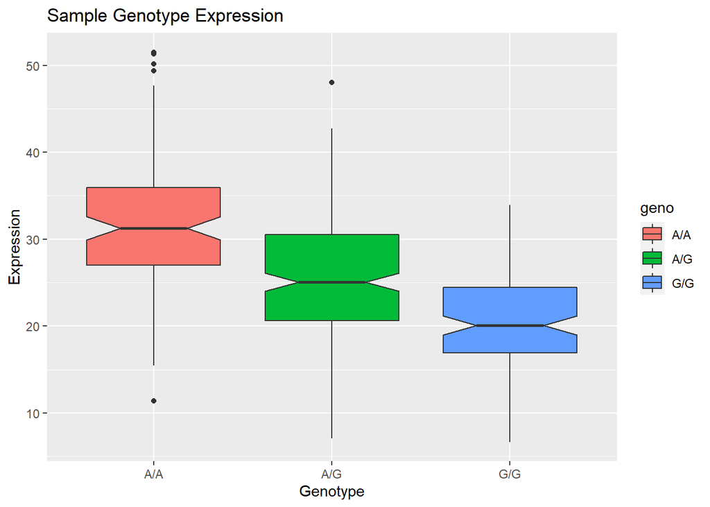

```r
library(ggplot2)
ggplot(expr, aes(geno, exp, fill=geno)) + geom_boxplot(notch=TRUE) + xlab("Genotype") + ylab("Expression") + labs(title="Sample Genotype Expression")
```

# Because the first and third quartiles of the A/A and G/G samples do not overlap, there is no major overlap between the G/G samples and A/A samples’ expression levels. Therefore, there is a significant difference in expression levels between the A/A and G/G samples, which means that the SNP does effect expression of ORMDL3.